Data Analysis:National Basketball Association

Recommendation of Chicago Bulls 5 best players

Contents

Introduction 2

Backgroundinformation.......................................... 2

Descriptionofthescenario......................................... 2

Theaimoftheproject........................................... 2

Justicationandimportance ....................................... 3

Reading and cleaning the raw data 3

Exploratory analysis 3

Checking for errors and missing values within the datasets . . . . . . . . . . . . . . . . . . . . . . . 3

Checking the distribution of variables . . . . . . . . . . . . . . . . . . . . . . . . . . . . . . . . . . 4

Distributionofplayers’age ..................................... 4

Distributionofplayers’points.................................... 5

Distributionofplayers’salary.................................... 5

Checking for relationships between variables . . . . . . . . . . . . . . . . . . . . . . . . . . . . . . . 6

Relationship between players’ points and salary . . . . . . . . . . . . . . . . . . . . . . . . . . 6

Relationship between players’ points and Age . . . . . . . . . . . . . . . . . . . . . . . . . . . 6

Relationship between age and positions . . . . . . . . . . . . . . . . . . . . . . . . . . . . . . 7

Relationship between salary and positions . . . . . . . . . . . . . . . . . . . . . . . . . . . . . 7

Relationship between perfomance(points) and positions . . . . . . . . . . . . . . . . . . . . . 8

Justication for decisions made about data modelling . . . . . . . . . . . . . . . . . . . . . . . . . 8

Data modelling and results 8

Datamodelling............................................... 8

Assumptionchecking............................................ 9

Linearrelationshipassumption ................................... 9

Normal distribution of errors assumption . . . . . . . . . . . . . . . . . . . . . . . . . . . . . . 10

Modeloutputandinterpretation ..................................... 10

Player recommendations 11

PlayerforPF................................................ 11

PlayerforC................................................. 12

PlayerforPG................................................ 12

PlayerforSF ................................................ 12

PlayerforSG................................................ 13

Summary 13

Reference 13

1

Introduction

Background information

Basketball is a team sport in which two teams, usually each with ve players, compete against one another

on a rectangular court with the main goal of preventing the opposing team from shooting through their own

hoop while putting the ball through the defender’s hoop, which is a basket with a diameter of 18 inches

(46 cm) mounted 10 feet (3.048 m) high to a backboard at each end of the court. Except when made from

behind the three-point line, a eld goal is worth three points(Roe, 2009). Timed play is stopped following a

foul, and the player who committed the foul or who was chosen to attempt a technical foul is awarded one,

two, or three one-point free throws.The team with the most points at the conclusion of regulation play wins,

but if the score is tied when regulation play ends, extra time (overtime) must be played(Roe, 2009).

Players move the ball forward by either passing it to a teammate or bouncing it while running or walking

(dribbling), both of which require a high level of ability. Players can employ a variety of shots on oense,

such as layups, jump shots, and dunks. On defense, they can steal the ball from a player who is dribbling,

intercept passes, or block shots(Roe, 2009). Finally, either the oense or the defense can grab rebounds,

which are missed shots that rebound o the rim or backboard. It is against the rules to carry the ball,

elevate or drag one’s pivot foot when not dribbling, or hold the ball in both hands before starting to dribble

again(Roe, 2009).

There are ve playing positions for each side’s ve players. The center is typically the tallest player, the

power forward is second tallest and strongest, the small forward is slightly shorter but more agile, and the

shooting guard and point guard are the shortest players or best ball handlers. The point guard executes the

coach’s game plan by managing the execution of oensive and defensive plays (player positioning). Players

can play one-on-one, two-on-two, and three-on-three informally(Radu & Nini, 2018).

Basketball was created in 1891 by Canadian-American gym instructor James Naismith in Springeld, Mas-

sachusetts, and has since grown to be one of the most well-liked and watched sports in the entire globe.

The National Basketball Association (NBA), which recruits the majority of its talent from American college

basketball, is the most signicant professional basketball league in terms of fandom, earnings, talent, and

level of competition(Radu & Nini, 2018).

The top teams from national leagues outside of North America are eligible to compete in continental com-

petitions like the EuroLeague and the Basketball Champions League Americas. The sport’s two biggest

international competitions, the Men’s Olympic Basketball Tournament and the FIBA Basketball World

Cup, draw the best national teams from all over the world. Regional competitions for national teams, such

as EuroBasket and the FIBA AmeriCup, are held on each continent(Radu & Nini, 2018).

Top national teams from continental championships compete in the Women’s Olympic Basketball Tourna-

ment and FIBA Women’s Basketball World Cup. The WNBA, along with the popular NCAA Women’s

Division I Basketball Championship, is the primary North American league, while the most powerful Euro-

pean clubs play in the EuroLeague Women(Taylor, 2012).

Description of the scenario

Chicago Bulls is one of the thirty teams which compete in National Basketball Association.In the most recent

NBA season (2018-19 as per study), the team was placed 27th out of 30 (based on win-loss record).The team’s

budget for player contracts next season(2019-20 as per study) is $118 million, ranked 26th out of 30.If the

team is in position 26 in terms of budget,we expect the team’s performance be 26 or any position between 1

and 26 but not 27.

The aim of the project

This study is aimed at nding the best ve starting players for Chicago Bulls basket ball team across all

the 30 teams putting into consideration various constraints such as team nancial constraint(budget).The

point guard (PG), shooting guard (SG), small forward (SF), power forward (PF), and center (C) are the

2

[figure not shown]

ve positions in basketball which are required to be lled at start. On the oor, each position has a unique

set of responsibilities, and the best basketball teams have incredible harmony between each position.

In order to choose these 5 players,it is crucial to understand whether the player’s performance depends

on the salary the team pays the player,the player’s age and even the position the player plays. With this

established,it would be quite easy to select and recommend the players.

Justication and importance

In the most recent NBA season (2018-19), Chicago Bulls basket ball team was placed 27th out of 30 (based

on win-loss record).The failure or success of a team depends on its players alongside with others such as

coach and key advisers. With an attempt to improve its performance,it was necessary to evaluate its players

and search out across the thirty teams,the best ve starting players.Poor performance of the team justices

the importance of the study to statistically analyse and recommend the best ve starting players putting

into considerations the team nancial constraint.

Reading and cleaning the raw data

The study uses NBA player statistics,NBA player salaries data set in order to achieve its aforemen-

tioned objective. These data sets were read into the R studio software by use of read.csv() function since the

les were already stored in CSV format.A text le with a specic format known as a CSV (comma-separated

values) le allows data to be saved in a table-structured format.

The data sets were then joined together into 1 data set using merge() function which is in multi-functional

tidyverse R package.

Using select() function,the study selected the only 6 variables or column which were of interest. These

columns include; * player_name-This columns shows the names of various players within the thirty national

teams. * Pos-This column shows the position in the eld which a given selected player plays * Age-This

column shows the age of the player in terms of years * Tm-This column shows the team in which the given

player plays * PTS-This column shows the performance of the player in terms of point given * Salary-This

column shows the salary earned by a given player

Table 1: Portion of the data

player_name Pos Age Tm PTS salary

Aaron Gordon PF 23 ORL 1246 21590909

Aaron Holiday PG 22 IND 294 1914480

Abdel Nader SF 25 OKC 241 1378242

Al-Farouq Aminu PF 28 POR 760 6957105

Al Horford C 32 BOS 925 28928710

Al Jeerson NA NA NA NA 4000000

Alan Williams PF 26 BRK 18 77250

Exploratory analysis

Checking for errors and missing values within the datasets

There are a total of 278 missing values in the data set to be used. There is no any missing value in the player

name,64 missing values in the pos column,64 missing values in Age,64 missing values in Tm,64 missing values

in PTS and 22 missing values in the salary column.This means that 36% of our data has missing values. We

therefore can not delete these values but instead deal with them through mean imputation. The columns

were already in correct data type and therefore no data types errors detected.

3

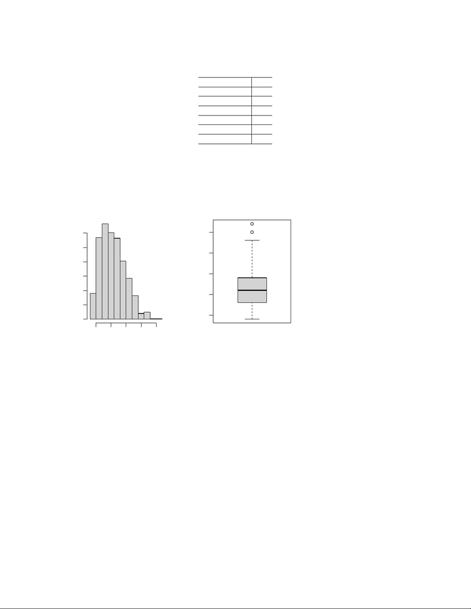

Table 2: Missing

NA

player_name 0

Pos 64

Age 64

Tm 64

PTS 64

salary 22

Checking the distribution of variables

Distribution of players’ age

Histogram of Age

Age

Frequency

20 25 30 35 40

0 20 40 60 80 120

20 25 30 35 40

players’ age seems to be almost normally distributed but slightly skewed to the right. Only two variables

are considered as extreme values of age.

4

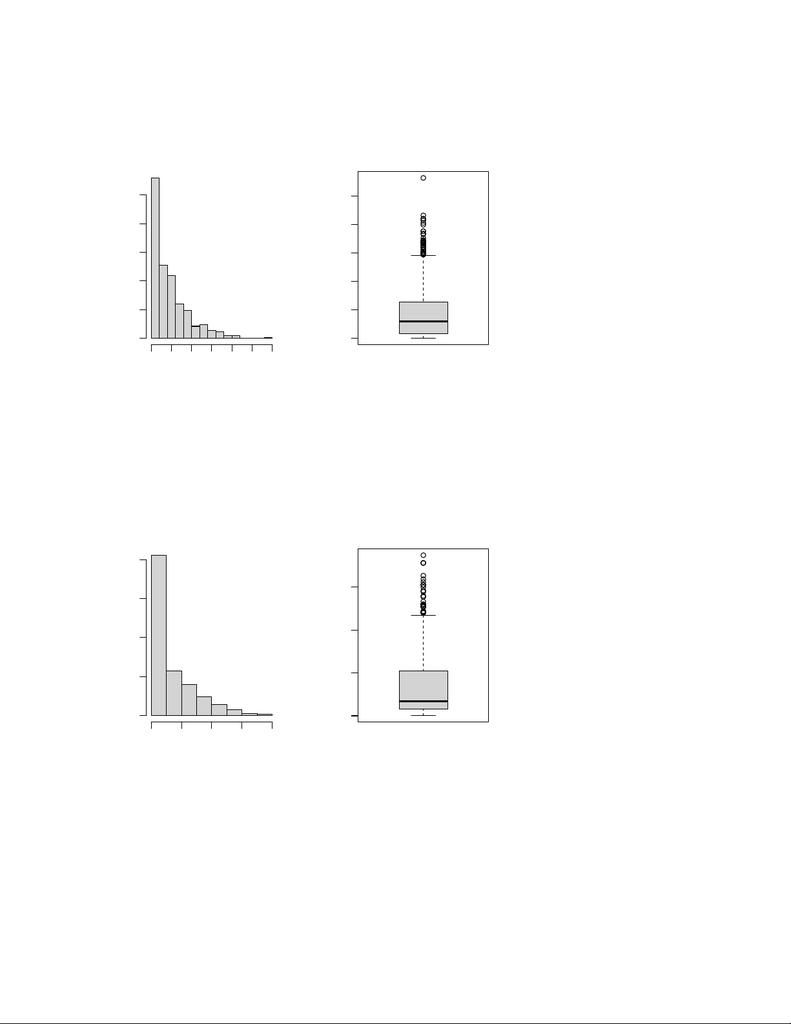

Distribution of players’ points

Histogram of points

Player points

Frequency

0 1000 2000 3000

0 50 100 150 200 250

0 500 1500 2500

The players’ points are not normally distributed. They are skewed to right.There seems to have several

outliers(extreme values) just above the maximum value.

Distribution of players’ salary

Histogram of salary

salary

Frequency

0e+00 2e+07 4e+07

0 100 200 300 400

0e+00 1e+07 2e+07 3e+07

The players’ salary is not normally distributed. They are skewed to right.There seems to have several

outliers(extreme values) just above the maximum value.

5

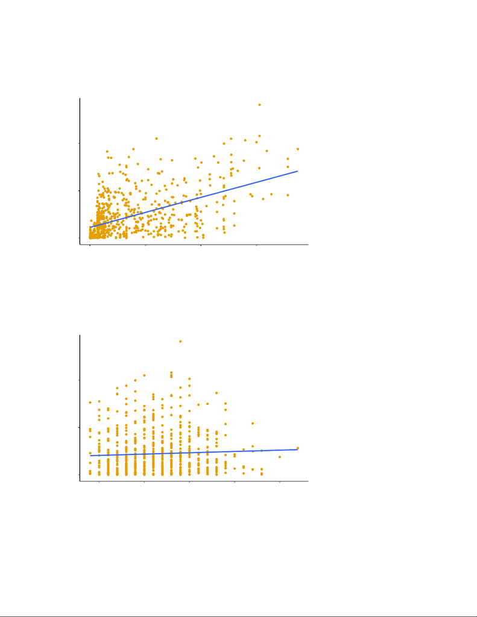

Checking for relationships between variables

Relationship between players’ points and salary

0

1000

2000

0e+00 1e+07 2e+07 3e+07

Salary

Perfomance in points

Relationship between players' points and salary

The scatter plot shows that there is a positive direct relationship between the players’ performance in terms

of points and salary. An increase in salary is associated with an increase in players’ points and the opposite

is true.

Relationship between players’ points and Age

0

1000

2000

20 25 30 35 40

Age

Perfomance in points

Relationship between players' points and age

6

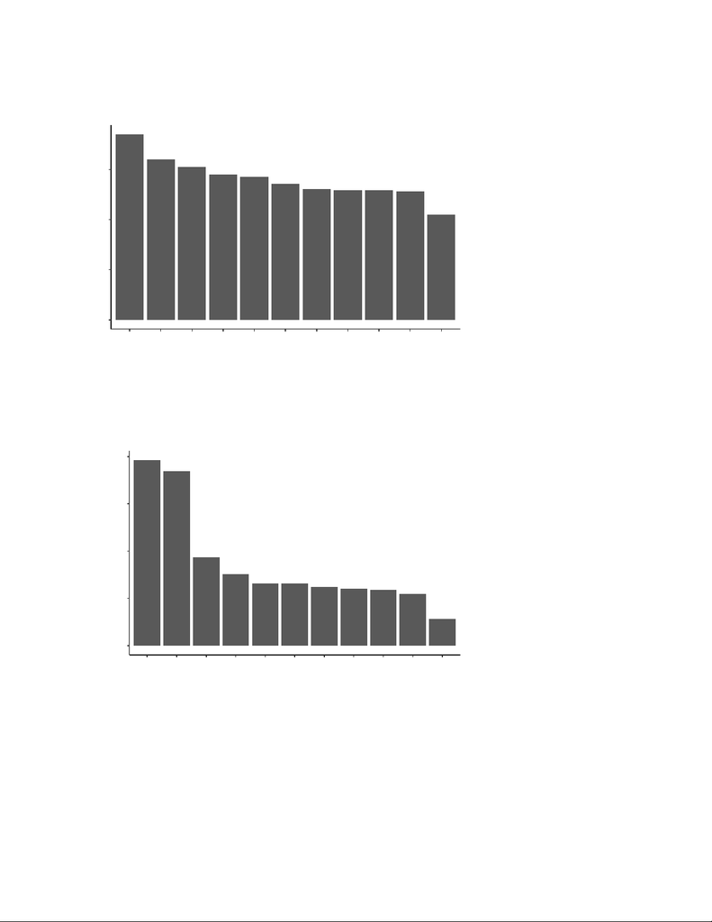

Relationship between age and positions

0

10

20

30

SG−PF

PF−C

SF−SG

SG−SF

PF−SF

C

PG

SF

SG

PF

C−PF

Field position

Age

Age vs field position

SG-PF seems to be the eld position with the aged players and C-PF seems to be the youngest.

Relationship between salary and positions

0.0e+00

5.0e+06

1.0e+07

1.5e+07

2.0e+07

SF−SG

PF−SF

C

SG−PF

SF

PG

PF

SG−SF

SG

PF−C

C−PF

Field position

Salary

Salary vs field position

SF-SG seems to be the position paid the highest salary amount and C-PF with the least salary amount.

7

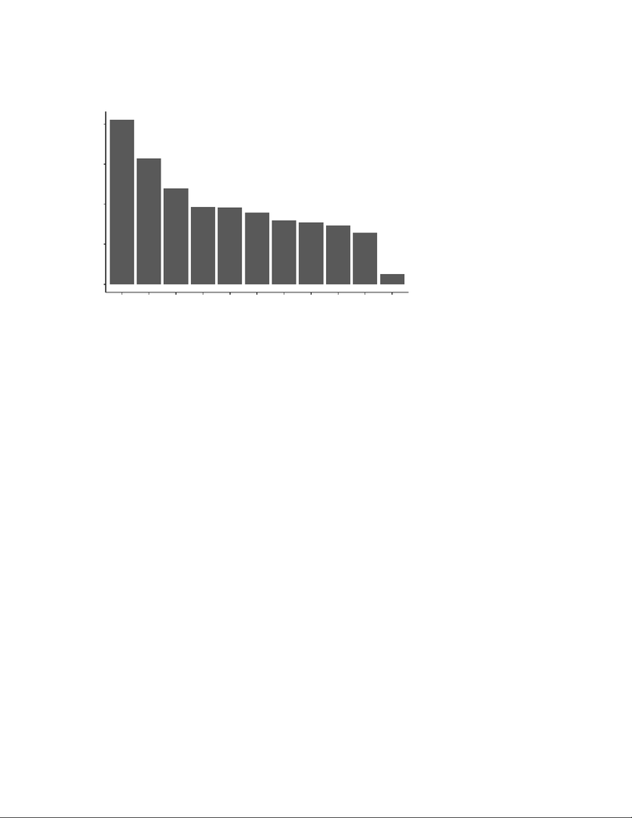

Relationship between perfomance(points) and positions

0

250

500

750

1000

SF−SG

PF−SF

SG−PF

C

PG

SG

SF

PF

SG−SF

C−PF

PF−C

Field position

Perfomance in points

Perfomance in points vs field position

SF-SG seems to be the best performing position and PF-C is the least performing position.

Justication for decisions made about data modelling

To understand whether the player’s performance depends on the salary the team pays the player,the player’s

age and even the position the player plays,we need to conduct a multiple linear regression. This is because

the modelling involves more than 1 independent variable and one dependent variable.

By tting a line to the observed data, regression models are used to describe relationships between variables.

You can estimate a dependent variable’s change as an independent variable or set of independent variables

changes using regression.

One dependent variable and two or more independent variables are estimated using multiple linear regression.

If you want to know how strongly a link exists between two or more independent variables and one dependent

variable, as well as how much the dependent variable changes when the independent variables change at a

particular level, you can use multiple linear regression.

Data modelling and results

Data modelling

##

## Call:

## lm(formula = PTS ~ salary + Age + Pos, data = player)

##

## Residuals:

## Min 1Q Median 3Q Max

## -868.90 -240.80 -78.42 190.21 1522.60

##

## Coefficients:

## Estimate Std. Error t value Pr(>|t|)

## (Intercept) 7.313e+02 1.032e+02 7.083 3.46e-12 ***

## salary 3.664e-05 2.059e-06 17.800 < 2e-16 ***

8

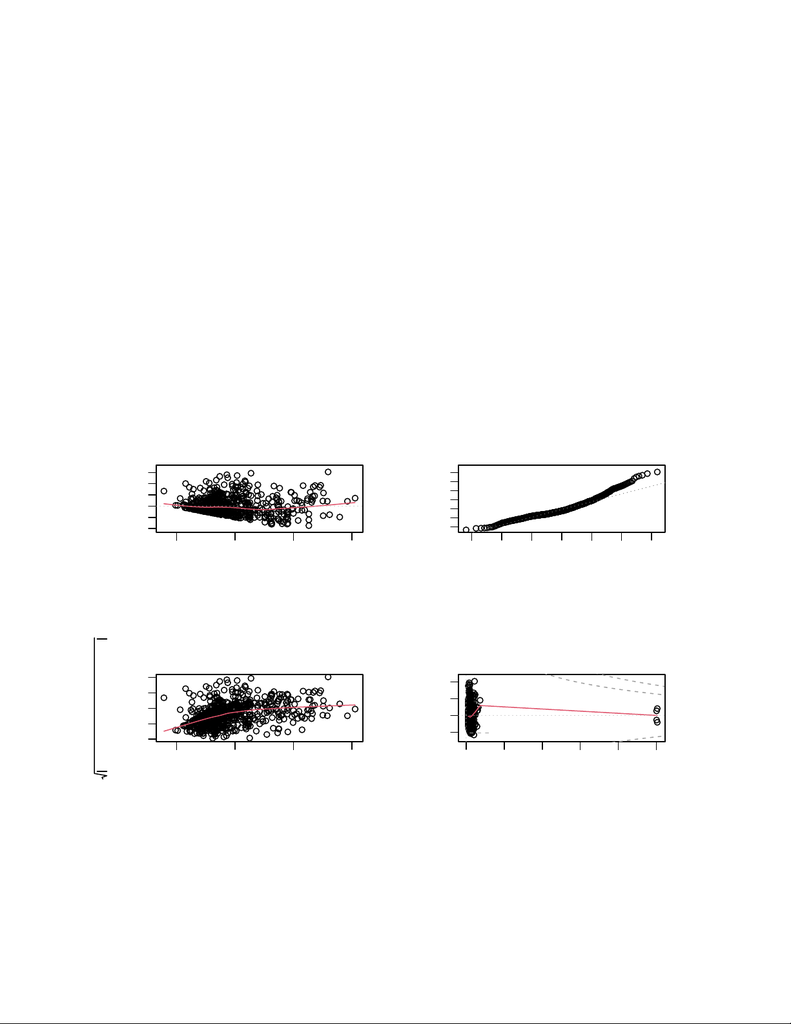

## Age -2.175e+01 3.791e+00 -5.737 1.44e-08 ***

## PosC-PF -5.418e+01 3.803e+02 -0.142 0.887

## PosPF -1.289e+01 4.701e+01 -0.274 0.784

## PosPF-C -1.701e+02 3.803e+02 -0.447 0.655

## PosPF-SF -2.676e+00 2.701e+02 -0.010 0.992

## PosPG 7.464e+01 4.745e+01 1.573 0.116

## PosSF -9.827e+00 4.936e+01 -0.199 0.842

## PosSF-SG 2.413e+02 2.703e+02 0.893 0.372

## PosSG 6.348e+01 4.529e+01 1.402 0.161

## PosSG-PF 3.963e+02 3.816e+02 1.039 0.299

## PosSG-SF 4.553e+01 3.798e+02 0.120 0.905

## ---

## Signif. codes: 0 '***' 0.001 '**' 0.01 '*' 0.05 '.' 0.1 ' ' 1

##

## Residual standard error: 378.1 on 695 degrees of freedom

## Multiple R-squared: 0.3242, Adjusted R-squared: 0.3125

## F-statistic: 27.78 on 12 and 695 DF, p-value: < 2.2e-16

Assumption checking

0 500 1000 1500

−1000 1000

Fitted values

Residuals

Residuals vs Fitted

311

424

193

−3 −2 −1 0 1 2 3

−2 1 3

Theoretical Quantiles

Standardized residuals

Normal Q−Q

311

424

193

0 500 1000 1500

0.0 1.0 2.0

Fitted values

Standardized residuals

Scale−Location

311

424

193

0.0 0.1 0.2 0.3 0.4 0.5

−2 2

Leverage

Standardized residuals

Cook's distance

0.5

0.5

1

Residuals vs Leverage

760

263

311

Linear relationship assumption

We will use Residuals vs Fitted plot to check this assumption. The residuals “bounce” about the 0 line

at random. This shows that it is plausible to assume that the relationship is linear. Around the 0 line, the

residuals generally form a “horizontal band.” This suggests that the error terms’ variances are equivalent.

From the fundamentally random pattern of residuals, no one residual “sticks out.” There might not be any

9

outliers, according to this.

Normal distribution of errors assumption

residuals is roughly equal. Additionally, we can conrm that there isn’t any discernible pattern in the

residuals. In other words, the residuals should have nearly similar variability at all tted values and be

randomly distributed around the red line, which is what happens in our situation.

Model output and interpretation

##

## Call:

## lm(formula = PTS ~ salary + Age + Pos, data = player)

##

## Residuals:

## Min 1Q Median 3Q Max

## -868.90 -240.80 -78.42 190.21 1522.60

##

## Coefficients:

## Estimate Std. Error t value Pr(>|t|)

## (Intercept) 7.313e+02 1.032e+02 7.083 3.46e-12 ***

## salary 3.664e-05 2.059e-06 17.800 < 2e-16 ***

## Age -2.175e+01 3.791e+00 -5.737 1.44e-08 ***

## PosC-PF -5.418e+01 3.803e+02 -0.142 0.887

## PosPF -1.289e+01 4.701e+01 -0.274 0.784

## PosPF-C -1.701e+02 3.803e+02 -0.447 0.655

## PosPF-SF -2.676e+00 2.701e+02 -0.010 0.992

## PosPG 7.464e+01 4.745e+01 1.573 0.116

## PosSF -9.827e+00 4.936e+01 -0.199 0.842

## PosSF-SG 2.413e+02 2.703e+02 0.893 0.372

## PosSG 6.348e+01 4.529e+01 1.402 0.161

## PosSG-PF 3.963e+02 3.816e+02 1.039 0.299

## PosSG-SF 4.553e+01 3.798e+02 0.120 0.905

## ---

## Signif. codes: 0 '***' 0.001 '**' 0.01 '*' 0.05 '.' 0.1 ' ' 1

##

## Residual standard error: 378.1 on 695 degrees of freedom

## Multiple R-squared: 0.3242, Adjusted R-squared: 0.3125

## F-statistic: 27.78 on 12 and 695 DF, p-value: < 2.2e-16

10

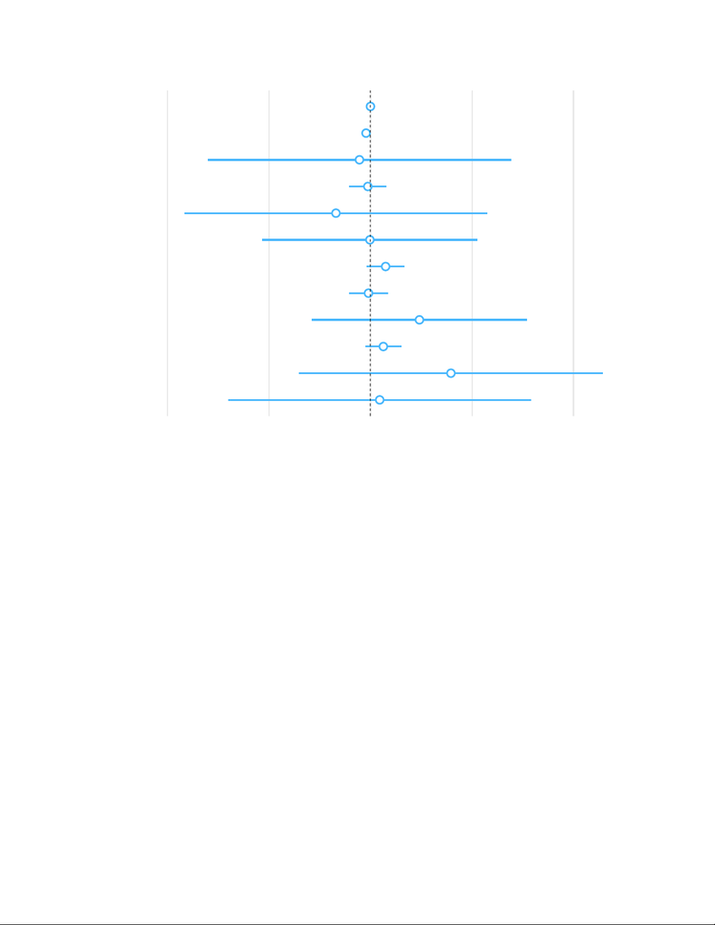

PosSG−SF

PosSG−PF

PosSG

PosSF−SG

PosSF

PosPG

PosPF−SF

PosPF−C

PosPF

PosC−PF

Age

salary

−1000 −500 0 500 1000

Estimate

According to the mode output we have F(12,695) = 27.78, p = 0.00. With small p-value,this model is

statistically signicant. From the model,only salary and age of a player signicantly predicts the players

performance in terms of points. This is because of their corresponding p-value which are less than 0.05 at

95% condence interval and 5% level of acceptance.

With a positive estimate for salary(3.664e-05),the average player’s performance in terms of points increases

unit increase in age holding all other factors constant.

Player recommendations

From the model output and interpretation,it is very clear that players who are well paid tend to perform

better. In addition,it is very clear that young players are expected to perform better as compared to old

players. Therefore,the player selection will be based on salary(restricting ourselves to budget below $118

million).

We will recommend one player per each position for the ve major positions;point guard (PG), shooting

guard (SG), small forward (SF), power forward (PF), and center (C). For each position,we will rst select

the top 5 players in terms of performance(measured in points). Out of the top 5 players,we will take the

youngest best performing.

Player for PF

Giannis Antetokounmpo(from MIL team) is the youngest best PF player. The player is 24 years old and is

paid a salary of $24157304.

11

[figure not shown]

Table 3: Top 5 PF players

player_name Pos Age Tm PTS salary

Giannis Antetokounmpo PF 24 MIL 1994 24157304

Blake Grin PF 29 DET 1841 31873932

Tobias Harris PF 26 TOT 1644 14800000

Julius Randle PF 24 NOP 1565 8641000

Pascal Siakam PF 24 TOR 1354 1544951

Player for C

Table 4: Top 5 C players

player_name Pos Age Tm PTS salary

Karl-Anthony Towns C 23 MIN 1880 7839435

Joel Embiid C 24 PHI 1761 25467250

LaMarcus Aldridge C 33 SAS 1727 22347015

Nikola Vucevic C 28 ORL 1665 12750000

Nikola Jokic C 23 DEN 1604 25467250

Karl-Anthony Towns(from MIN team) is the youngest best center player who is aged 23 years old.The player

is paid a salary of $7839435.

Player for PG

Table 5: Top 5 PG players

player_name Pos Age Tm PTS salary

James Harden PG 29 HOU 2818 30570000

Kemba Walker PG 28 CHO 2102 12000000

Damian Lillard PG 28 POR 2067 27977689

Stephen Curry PG 30 GSW 1881 37457154

D’Angelo Russell PG 22 BRK 1712 7019698

D’Angelo Russell(from BRK team) is the youngest best PG player. The player is 22 years old and is paid a

salary of $7019698.

Player for SF

Table 6: Top 5 SF players

player_name Pos Age Tm PTS salary

Paul George SF 28 OKC 2159 30560700

Kevin Durant SF 30 GSW 2027 30000000

Kawhi Leonard SF 27 TOR 1596 23114066

LeBron James SF 34 LAL 1505 35654150

Bojan Bogdanovic SF 29 IND 1454 10500000

12

[figure not shown]

Player for SG

Table 7: Top 5 SG players

player_name Pos Age Tm PTS salary

Bradley Beal SG 25 WAS 2099 25434262

Donovan Mitchell SG 22 UTA 1829 3111480

Devin Booker SG 22 PHO 1700 3314365

Buddy Hield SG 26 SAC 1695 3833760

Klay Thompson SG 28 GSW 1680 18988725

The total budget for the 5 players is $ 65241983. This is just 55.29% of the total proposed budget of %118

million.

Summary

The study investigated the key factors which should be considered when selecting the best 5 players apart

from their points earned(performance). Using performance alone,can bring the best 5 players but the total

budget can surpluses the allocated budget of $118 million. The study found that age and salary paid to a

player signicantly aect the player’s performance.

5 players were selected best on the 5 major positions in basket ball. For each position,we selected the top

5 players in terms of performance(measured in points). Out of the top 5 players,we took the youngest best

performing player. Therefore the 5 reccommnded players are;

• PF-Giannis Antetokounmpo(from MIL team) is the youngest best PF player. The player is 24 years

old and is paid a salary of $24157304.

• Center-Karl-Anthony Towns(from MIN team) is the youngest best center player who is aged 23 years

old.The player is paid a salary of $7839435.

• PG-D’Angelo Russell(from BRK team) is the youngest best PG player. The player is 22 years old and

is paid a salary of $7019698.

Reference

Radu, A., & Nini, F. (2018). Women’s basketball. THE Science of Basketball, 127–142. https://doi.org/10.

4324/9781315204000-6

Roe, D. (2009). Basketball. African American Studies Center. https://doi.org/10.1093/acref/

9780195301731.013.45253

Taylor, L. (2012). Competing risks in basketball … competing risks in basketball … competing risks in

basketball …. CHANCE, 25(2), 31–36. https://doi.org/10.1080/09332480.2012.685367

13